# Desafio para processo seletivo em análise de dados

Vinicius Soares

25/04/2024

Abrindo as bases de dados:

```r
distritos <- read_csv(file = "dados/geosampa_distritos.csv")
familias_extrema_pobreza <- read_csv("dados/observasampa_familias_extrema_pobreza.csv")
```

Criando uma base de dados unificada:

```r
fam_extpobreza_distrito <- left_join(familias_extrema_pobreza, distritos, "ds_nome")
```

## Questões

#### 1. Quantas famílias em situação de extrema pobreza existiam em São Paulo em 2023?

Em São Paulo, em 2023, havia **765.114** famílias em situação de extrema pobreza.

```r
df_23 <-
  fam_extpobreza_distrito %>%
  filter(ano == "2023")

total_2023 <- sum(df_23$qtd_familias)
total_2023
```

```
## [1] 765114
```

#### 2. Qual o percentual (em relação ao total da cidade) de famílias em situação de extrema pobreza por Distrito em 2023?

```r
df_23 %>%
  mutate(perc_distrito = (qtd_familias/total_2023)*100) %>%
  select(!ds_nome & !ds_sigla & !ds_subpref) %>%
  arrange(-perc_distrito)
```

| distrito | ano | qtd_familias | perc_distrito |
| --- | --- | --- | --- |
| Grajaú | 2023 | 34028 | 4.44744182 |
| Jardim Ângela | 2023 | 29158 | 3.81093536 |
| Cidade Ademar | 2023 | 27075 | 3.53868835 |
| Sapopemba | 2023 | 24467 | 3.19782412 |
| Brasilândia | 2023 | 24146 | 3.15586958 |
| Itaim Paulista | 2023 | 23023 | 3.00909407 |
| Cidade Tiradentes | 2023 | 22712 | 2.96844653 |
| Jaraguá | 2023 | 18553 | 2.42486741 |
| Lajeado | 2023 | 18354 | 2.39885821 |
| Jardim São Luís | 2023 | 17873 | 2.33599176 |

[output cut: 86 more lines]

#### 3. Qual distrito apresentou o maior aumento de famílias em situação de pobreza entre 2022 e 2023?

O distrito que apresentou o maior aumento de famílias em situação de extrema pobreza entre 2022 e 2023 foi o **Grajaú**, com um aumento absoluto de 5812 famílias nessa situação.

```r
df_22 <-
  fam_extpobreza_distrito %>%
  filter(ano == "2022")

df_22_23 <-
  left_join(df_23, df_22, "ds_nome") %>%
  select(distrito.x, qtd_familias.y, qtd_familias.x, ds_nome, ds_subpref.x) %>%
  mutate(dif_22_23 = df_23$qtd_familias - df_22$qtd_familias) %>%
  rename("distrito" = distrito.x, "qtd_familias_2023" = qtd_familias.x, "qtd_familias_2022" = qtd_familias.y, "ds_subpref" = ds_subpref.x)

df_22_23 %>%
  summarise(distrito, qtd_familias_2022, qtd_familias_2023, dif_22_23) %>%
  arrange(-dif_22_23)
```

| distrito | qtd_familias_2022 | qtd_familias_2023 | dif_22_23 |
| --- | --- | --- | --- |
| Grajaú | 28216 | 34028 | 5812 |
| Brasilândia | 19557 | 24146 | 4589 |
| Sapopemba | 20227 | 24467 | 4240 |
| Cidade Ademar | 22968 | 27075 | 4107 |
| Itaim Paulista | 18943 | 23023 | 4080 |
| Parelheiros | 12466 | 16314 | 3848 |
| Lajeado | 14727 | 18354 | 3627 |
| Itaquera | 11706 | 15296 | 3590 |
| Jardim Helena | 11385 | 14915 | 3530 |
| Jardim Ângela | 25653 | 29158 | 3505 |

[output cut: 86 more lines]

#### 4. Quantas famílias em situação de extrema pobreza existiam em cada Subprefeitura de São Paulo em 2023?

```r
df_23 %>%
  group_by(ds_subpref) %>%
  summarise(sum(qtd_familias)) %>%
  rename("qtd_subpref" = "sum(qtd_familias)") %>%
  arrange(-qtd_subpref) %>%
  rename("Subprefeitura" = ds_subpref, "Quantidade" = qtd_subpref) %>%
  ungroup()
```

| Subprefeitura | Quantidade |
| --- | --- |
| CAPELA DO SOCORRO | 47173 |
| M BOI MIRIM | 47031 |
| CIDADE ADEMAR | 44446 |
| SAO MATEUS | 41585 |
| ITAQUERA | 39223 |
| CAMPO LIMPO | 38395 |
| ITAIM PAULISTA | 37587 |
| SAO MIGUEL | 35508 |
| FREGUESIA-BRASILANDIA | 31033 |
| PIRITUBA-JARAGUA | 30399 |

[output cut: 22 more lines]

#### 5. Como variou o número de famílias em situação de pobreza entre 2013 e 2023 nos Distritos de Grajaú, Jardim Ângela, Cidade Ademar? Exiba graficamente o resultado, escolhendo a visualização que achar mais adequada.

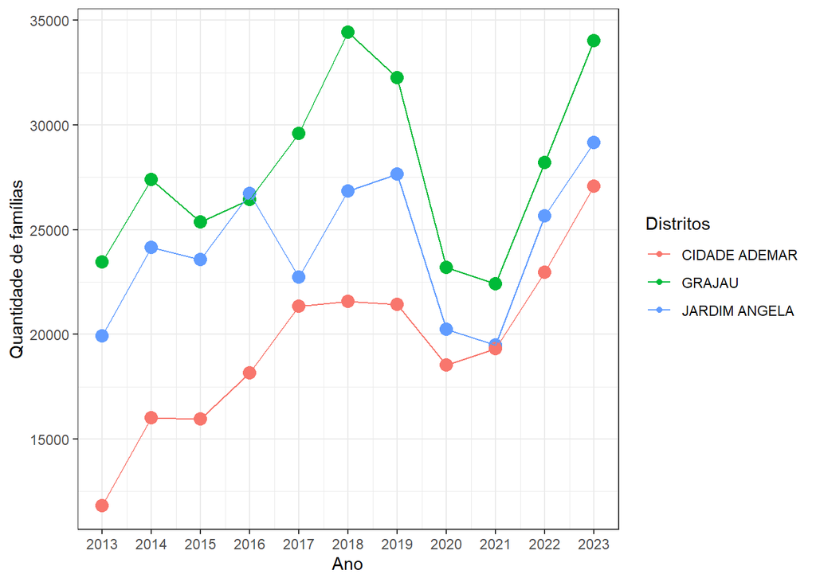

```r
fam_extpobreza_distrito %>%
  filter(ds_nome == "GRAJAU" | ds_nome == "CIDADE ADEMAR" | ds_nome == "JARDIM ANGELA") %>%
  ggplot() +
  geom_point(aes(x = ano, y = qtd_familias, color = ds_nome, stroke = 2)) +
  geom_line(aes(x = ano, y = qtd_familias, group = ds_nome, color = ds_nome)) +
  scale_x_continuous(breaks = seq(2013, 2023, 1)) +
  labs(x = "Ano", y = "Quantidade de famílias", color = "Distritos") +
  theme_bw()
```

#### 6. Complete a seguinte frase: “De acordo com os dados do ObservaSampa, em 2023, metade dos Distritos de São Paulo, no máximo, ___ famílias em situação de extrema pobreza”. Qual informação você utilizou para completar a frase?

```r
summary(df_23$qtd_familias)
```

```
##    Min. 1st Qu.  Median    Mean 3rd Qu.    Max.
##     205    2779    5610    7970   11974   34028
```

“De acordo com os dados do ObservaSampa, em 2023, metade dos Distritos de São Paulo possuía, no máximo, **5610** famílias em situação de extrema pobreza”.

Esse valor foi encontrado a partir da mediana - ou segundo quartil -, medida de centralidade que indica exatamente o valor que separa a amostra na metade. Assim, essa estatística indica o valor que complementa adequadamente a frase.